# Introducción y Regresión

José Fernando Zea

12/8/2020

- Pronosticar la probabilidad de que un paciente pueda agravarse como consecuencia del COVID 19. (Siempre y cuando exista).
- Segmentar clientes basados en atributos comunes y en comportamientos de compra.
- Predecir la probabilidad de que un empleado abandone una organización.
- Predecir una fuga de cliente con información del cliente (churn analysis).
- Cuantificar la probabilidad de falla de un dispositivo.
- Predecir si un cliente va a estar en mora en los próximos meses.

## Aprendizaje supervisado

En un modelo predictivo implica la predicción de una variable en términos de otras variables. Por ejemplo el valor de una vivienda se puede predecir en términos de diferentes atributos de la vivienda. En estos modelos predictivos se dispone de variables predictivas (X), que producen una variable respuesta.

- Las variables predictivas se conocen también como variable independiente, atributo, feature, predictor.
- Las variables objetivo se conocen como variable dependiente, respuesta.

Los modelos anteriormente descritos se conocen como modelos de aprendizaje supervisado. La palabra *supervisado* refleja el hecho de que la variable objetivo auxilia o supervisa el aprendizaje. Dados los datos, el algoritmo de aprendizaje optimiza una función para encontrar una combinación de las variables (features) que esté lo más cercano al valor verdadero de la variable objetivo.

La mayoría de los modelos supervisados se pueden clasificar en dos clases de modelos:

- Problemas de regresión

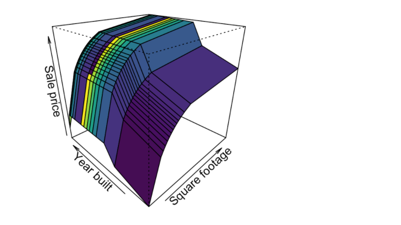

En este caso el pronostico del resultado a predecir es una variable continua. Por ejemplo en el pronostico del precio de una vivienda, la variable a predecir es continua y dada las combinaciónes de los predictores el valor que se generará estará en el dominio de los reales.

- Problemas de clasificación

Cuando la variable a predecir es categórica el problema se denomina un problema *de clasificación*, algunos ejemplos de este tipo de pronósticos son:

- Clasificar si una persona tomará un crédito que oferte un banco.
- Clasificar si una persona ingresará en cuidados intensivos basado en su información sociodemográfica.

## Aprendizaje no supervisado

- No hay etiquetas.
- Creación de clusters
- Técnicas de reducción de dimensionalidad

## Mínimos cuadrados

$$y_i = \beta_0+\beta_1x_i+e_i=\hat{y}_i+e_i$$

$i = 1,\ldots n$

$e_i = y_i - \hat{y}_i$, la diferencia entre el valor real y el valor pronosticado es el error.

## Minimizar la suma de cuadrados del error

$$MSE = \frac{1}{n}\sum_{i=1}^{n}e_i^2 = \frac{1}{n}\sum_{i=1}^{n}(y_i - \beta_0-\beta_1x_i)^2$$
$$f(\beta_0, \beta_1) = \frac{1}{n}\sum_{i=1}^{n}(y_i - \beta_0-\beta_1x_i)^2$$
$$f(x, y) = \frac{1}{n}\sum_{i=1}^{n}(peso_i - x - y * estatura_i)^2$$

- Objetivo: Encontrar los $\mathbf{\beta}$ que minimizan el MSE.
- Paso 1A: derivar MSE con respecto $\beta_0$ e igualar a 0
- Paso 1B: derivar MSE con respecto $\beta_1$ e igualar a 0

$$\frac{d}{d\beta_0}\left(\frac{1}{n}\sum_i^{n}(y_i - \beta_0+\beta_1x_i)^2\right) = 0 =\frac{1}{n} \sum_{i=1}^{n}-2(y_i- \beta_0-\beta_1x_i)=0$$
$$\frac{1}{n}\frac{d}{d\beta_1} \left(\sum_i^{n}(y_i - \beta_0+\beta_1x_i)^2\right)= 0= \frac{1}{n}\sum_{i=1}^{n}-2(y_i- \beta_0-\beta_1x_i)x_i=0$$
Paso 2: Despejar $\beta_0$ y $\beta_1$

Despejando Beta 0 de la primera ecuación

$$\hat{\beta_0} = \sum_{i=1}^{n}(y_i- \beta_1x_i)=0 = \overline{y}-\beta_1\overline{x}$$
$$\hat{\beta_1}=\frac{\sum_{i=1}^n(x_i-\overline{x})(y_i-\overline{y})/n}{\sum_{i=1}^n(x_i-\overline{x})^2/n}$$

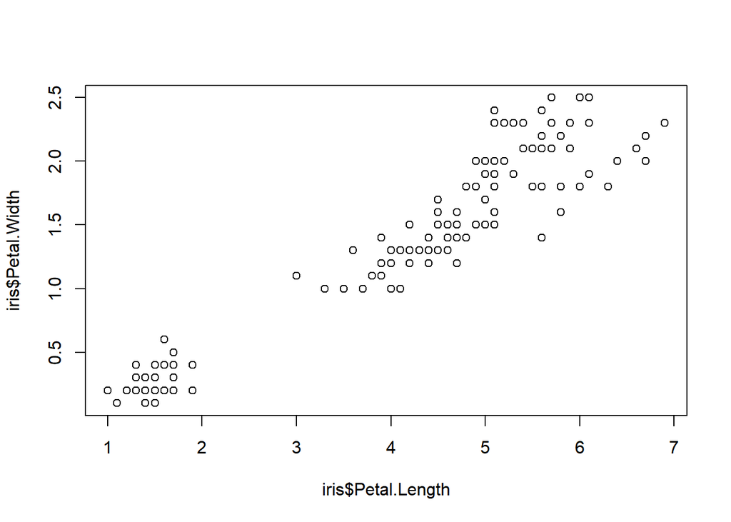

```r
data(iris)
# x: ancho del petalo, y: longitud del petalo
plot(iris$Petal.Width ~ iris$Petal.Length )
```

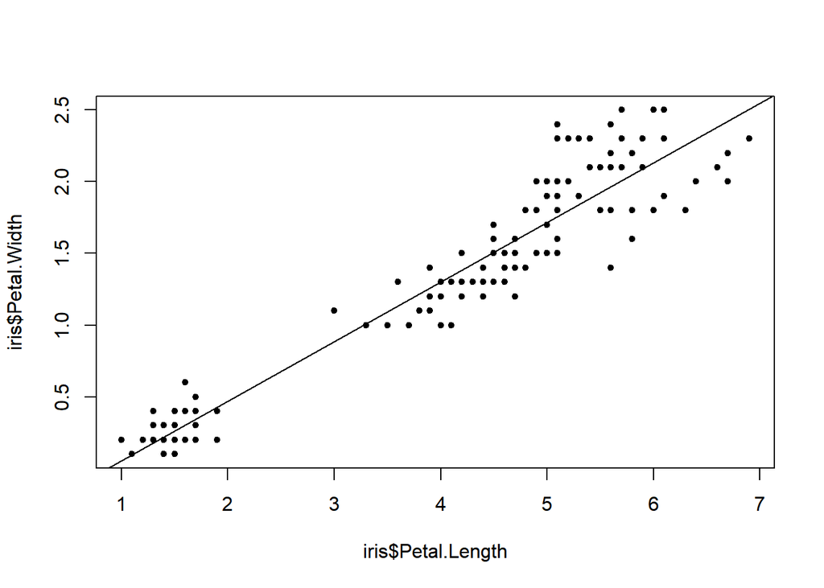

```r
modelo <- lm(iris$Petal.Width ~ iris$Petal.Length , data = iris)
plot(iris$Petal.Width ~ iris$Petal.Length, pch = 20 )
abline(modelo)
```

```r
summary(modelo)
```

```
##
## Call:
## lm(formula = iris$Petal.Width ~ iris$Petal.Length, data = iris)
##
## Residuals:
##      Min       1Q   Median       3Q      Max
## -0.56515 -0.12358 -0.01898  0.13288  0.64272
##
## Coefficients:
##                    Estimate Std. Error t value Pr(>|t|)
## (Intercept)       -0.363076   0.039762  -9.131  4.7e-16 ***
## iris$Petal.Length  0.415755   0.009582  43.387  < 2e-16 ***
## ---
## Signif. codes:  0 '***' 0.001 '**' 0.01 '*' 0.05 '.' 0.1 ' ' 1
##
## Residual standard error: 0.2065 on 148 degrees of freedom
## Multiple R-squared:  0.9271, Adjusted R-squared:  0.9266
## F-statistic:  1882 on 1 and 148 DF,  p-value: < 2.2e-16
```

```r
beta1 <- cov(iris$Petal.Length, iris$Petal.Width) / var(iris$Petal.Length)
beta1
```

```
## [1] 0.4157554
```

```r
beta0 <- mean(iris$Petal.Width) - beta1 * mean(iris$Petal.Length)
beta0
```

```
## [1] -0.3630755
```

Igual que el procedimieno de R :)

### Se puede resolver con un paquete de optimización

Minimizar:
$$MSE = \sum_{i=1}^{n}e_i^2 = \sum_{i=1}^{n}(y_i - \beta_0-\beta_1x_i)^2$$

```r
data(iris)
beta_inicial <- c(0, 30)

library(nloptr)
x <- iris$Petal.Length
y <- iris$Petal.Width

mse <- function(beta){
  sum((y -  beta[1] -  beta[2]*x)^2)
}

# Sin restricción

opts = list("algorithm" = "NLOPT_LN_BOBYQA", "xtol_rel" = 1.0e-8,
              "maxeval" = 10000)

nloptr(x0 = beta_inicial, eval_f = mse,
       eval_grad_f = NULL, opts = opts)
```

```
##
## Call:
## nloptr(x0 = beta_inicial, eval_f = mse, eval_grad_f = NULL, opts = opts)
##
##
##
## Minimization using NLopt version 2.4.2
##
## NLopt solver status: 4 ( NLOPT_XTOL_REACHED: Optimization stopped because
## xtol_rel or xtol_abs (above) was reached. )
##
## Number of Iterations....: 45
## Termination conditions:  xtol_rel: 1e-08 maxeval: 10000
## Number of inequality constraints:  0
## Number of equality constraints:    0
## Optimal value of objective function:  6.31009637924898
## Optimal value of controls: -0.3630755 0.4157554
```

```r
# Regresión Con restricciones poner el beta_0 casi igual a cero
beta_inicial <- c(0, 30)
opts = list("algorithm" = "NLOPT_LN_BOBYQA", "xtol_rel" = 1.0e-8,
              "maxeval" = 10000)

nloptr(x0 = beta_inicial, eval_f = mse, lb = c(-0.01,-Inf), ub = c(0.01,Inf),
       eval_grad_f = NULL, opts = opts)
```

```
##
## Call:
##
## nloptr(x0 = beta_inicial, eval_f = mse, eval_grad_f = NULL, lb = c(-0.01,
##     -Inf), ub = c(0.01, Inf), opts = opts)
##
##
## Minimization using NLopt version 2.4.2
##
## NLopt solver status: 4 ( NLOPT_XTOL_REACHED: Optimization stopped because
## xtol_rel or xtol_abs (above) was reached. )
##
## Number of Iterations....: 41
## Termination conditions:  xtol_rel: 1e-08 maxeval: 10000
## Number of inequality constraints:  0
## Number of equality constraints:    0
## Optimal value of objective function:  9.6719072296154
## Optimal value of controls: -0.01 0.3386935
```

## Método de gradiente

```r
datos <- read.csv("houses_portland.csv")
head(datos)
```

```
##   area bedroom  price
## 1 2104       3 399900
## 2 1600       3 329900
## 3 2400       3 369000
## 4 1416       2 232000
## 5 3000       4 539900
## 6 1985       4 299900
```

Se analizará la relación entre el área y el precio de unas viviendas:

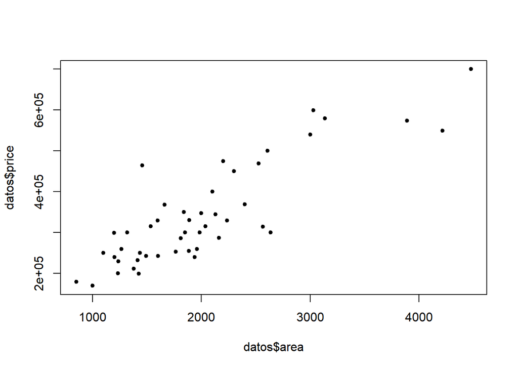

```r
plot(datos$area, datos$price, pch = 20)
```

Dadas las unidades tan diferentes de las dos variables, éstas se estandarizan:

```r
datos$area_st <- (datos$area - mean(datos$area)) / sd(datos$area)
datos$price_st <- (datos$price - mean(datos$price)) / sd(datos$price)
```

Las relaciones no se afectan

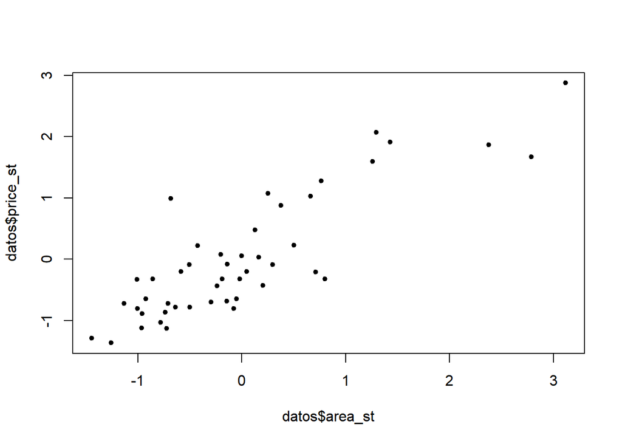

```r
plot(datos$area_st, datos$price_st, pch = 20)
```

El modelo de regresión lineal toma la siguiente forma:

$$y=\beta_0 + \beta_1 x_1 + \beta_2 x_2 + \dots + \beta_p x_p$$
, donde:

- y es la respuesta
- $\beta_0$ es el intercepto
- $\beta_1$ es el coeficiente asociado a $x_1$
- $\beta_p$ es el coeficiente asociado a $x_p$

Los valores de $\beta$ se conocen como los coeficientes de regresión. Estos valores se estiman en un proceso de ajuste usando la función de perdida cuadrático:

$$\sum_{i=1}^{n}(\hat{y}_i-y_i)^2$$

Esta función de perdida se conoce como suma de cuadrados del error.

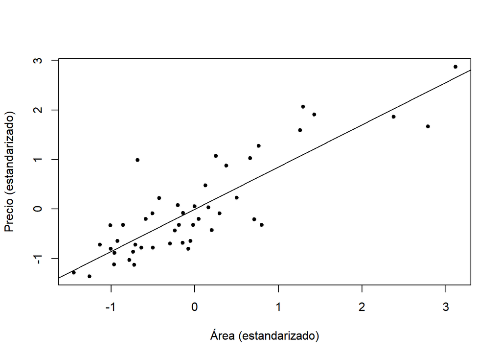

```r
modelo <- lm(price_st ~ area_st, data = datos)
plot(datos$area_st, datos$price_st, pch = 20, xlab = "Área (estandarizado)", ylab = "Precio (estandarizado)")
abline(modelo)
```

# Introducción gradiente descendente

El algoritmo *gradiente descendente* se utiliza para encontrar máximos y mínimos de una función. Su nombre viene dado por que si fuéramos por ejemplo unos seres bidimensionales y quisiéramos encontrar el punto más bajo de una curva, por ejemplo una parábola, empezaríamos a descender si encontramos pendientes positivas, ese descenso se traduce en trasladarse hacia la izquierda. Por otro, si la pendiente fuera negativa, empezaríamos de igual forma a descender pero esto se traduce en moverse hacia la derecha.

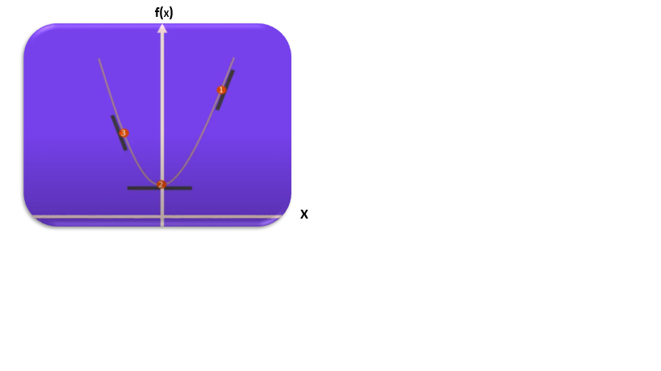

El algoritmo de gradiente descentende se puede escribir como sigue:

$$x^{(i+1)} = x^{(i)}-\alpha\frac{d}{dx^{(i)}}f(x^{(i)})$$
En esta formulación $x^{(i+1)}$ hace referencia a la iésima iteración, se comienza con un punto arbitrario llamado $x^{(0)}$, en este algoritmo existe un parámetro denominado la tasa de aprendizaje $\alpha$. Después de varias iteraciones se encontrará la solución que minimiza la curva.

En el caso multivariado, este algoritmo se puede escribir como:

$$\mathbf{x}^{(i+1)}=\mathbf{x}^{(i)}-\alpha\nabla F(x)$$

O escrito en términos de las derivadas parciales:

$$\left(x_1^{(i+1)},\ldots x_p^{(i+1)}\right)'=\left(x_1^{(i)},\ldots x_p^{(i)}\right)' -\alpha \left( \frac{\partial f(x_1\ldots x_p)}{\partial x_1}, \ldots \frac{\partial f(x_p\ldots x_p)}{\partial x_1}\right)'$$

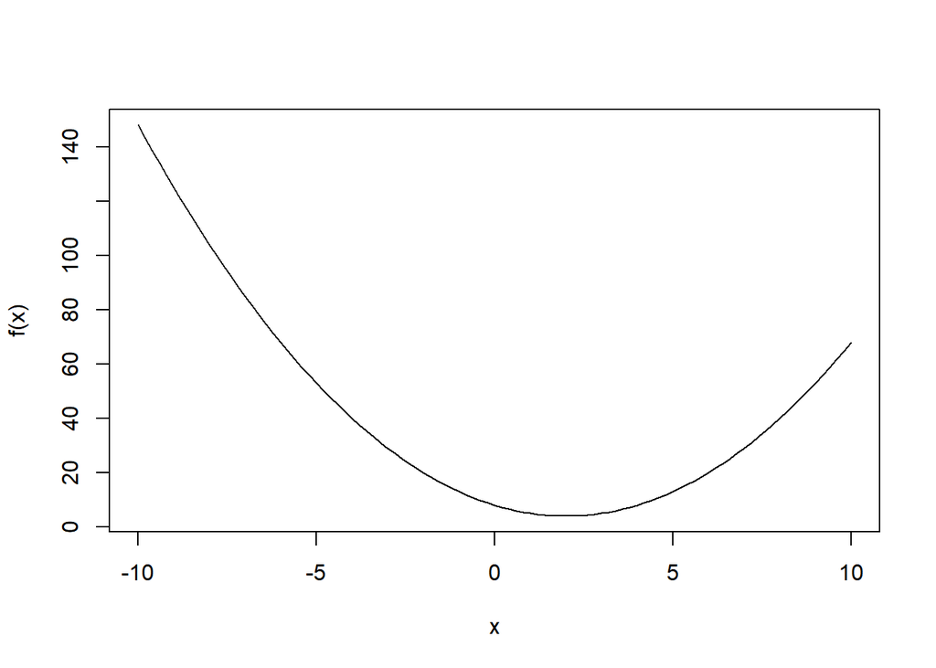

```r
#curve(sin(x))
f <- function(x) {4+(x-2)^2}
curve(f(x), xlim = c(-10, 10))
```

La derivada de esa función es:

Definimos las dos funciones

```r
f <- function(x) {x^2 - 2*x + 8}
fprima <- function(x) {2*x -2}
```

Aplicamos el algoritmo iterativo:

$$x^{(i+1)}:=x^{(i)}-\alpha\frac{df(x^{(i)})}{dx^{(i)}}$$

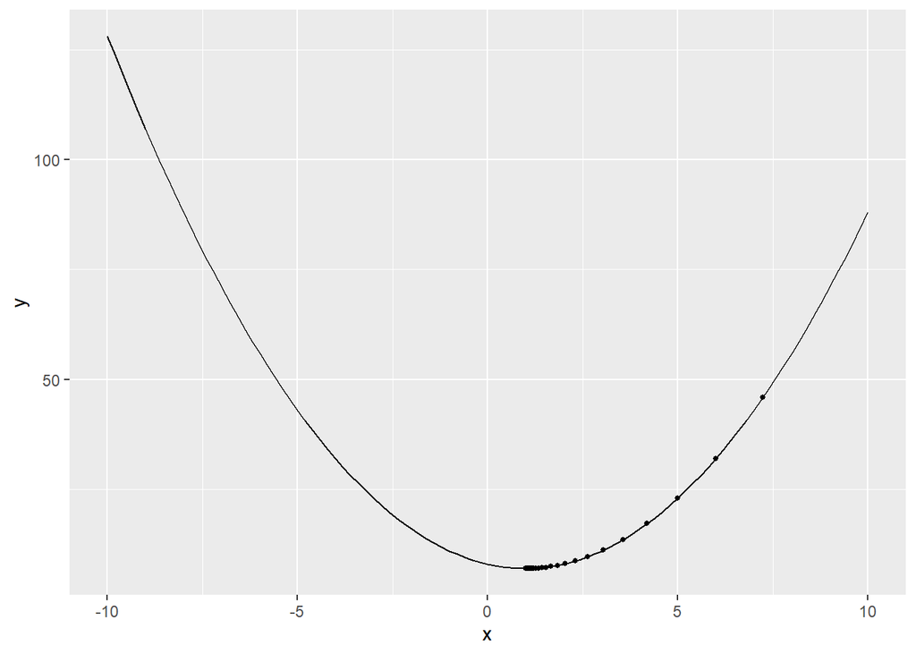

```r
set.seed(12345)
xprevio <- round(runif(n = 1, min = -20, max = 20), 1)
alpha <- 0.1

iteracion <- 0
grafico <- ggplot(data.frame(x = c(-10, 10)), aes(x = x)) +
        stat_function(fun = f)
x_i <- xprevio -  alpha * fprima(xprevio)

while(abs(x_i-xprevio) >  1e-12){
  xprevio <- x_i
  df <- data.frame(iter = 1, x_i = x_i, f = f(x_i))

  x_i <- xprevio -  alpha * fprima(xprevio)
  actualizacion <- c(iter = 2, x_i = x_i, f = f(x_i))
  df <- rbind(df, actualizacion)
  grafico <- grafico + geom_point(data = df,
               mapping = aes(x = x_i, y = f), size = 1)
}
grafico
```

La técnica de gradiente descendiente puede escribirse como una función en términos de la tolerancia, el valor inicial y del valor de castigo $\alpha$.

Colocaremos un valor arbitrario de inicialización:

```r
gduniv <- function(f, x_inicial, alpha, tolerancia = 1e-12){
  fprima <- Deriv::Deriv(f)
  xprevio <- x_inicial
  iteracion <- 0
  x_i <- xprevio -  alpha * fprima(xprevio)

  while(abs(x_i-xprevio) > tolerancia){
    xprevio <- x_i
    x_i <- xprevio -  alpha * fprima(xprevio)
    iteracion <- iteracion + 1
  }
resultado <- list(x_i, iteracion)
names(resultado) <- c("sol", "iter")
return(resultado)
}
```

Solución a nuestro problema:

```r
f <- function(x) x^2 - 2*x + 8
gduniv(f, x_inicial = 8, alpha = 0.1)
```

```
## $sol
## [1] 1
##
## $iter
## [1] 126
```

# Función de costo

El objetivo que se quiere lograr en un problema de predicción, es encontrar los parámetros que minimiza la suma de cuadrados del error:

$$C(\beta_0, \beta_1) = \frac{1}{n} \sum_{i=1}^{n}(y_i-\hat{y}_i)^2=\frac{1}{n}\sum_{i=1}^{n}(y_i-\hat{\beta}_0-\hat{\beta}_1x_i)^2$$

La derivada de la función de costo con respecto a $\hat{\beta}_0$ y $\hat{\beta}_1$:
$$\frac{\partial C(\beta_0, \beta_1) }{\partial \beta_0}=\frac{1}{n}\frac{\partial \sum_{i=1}^{n}(y_i-\hat{\beta}_0-\hat{\beta}_1x_i)^2}{\partial \beta_0}=\frac{1}{n} \sum_{i=1}^{n}-2(y_i-\hat{\beta}_0-\hat{\beta}_1x_i)=0$$
$$\frac{\partial C(\beta_0, \beta_1) }{\partial \beta_1}=\frac{1}{n}\frac{\partial \sum_{i=1}^{n}(y_i-\hat{\beta}_0-\hat{\beta}_1x_i)^2}{\partial \beta_1}=\frac{1}{n} \sum_{i=1}^{n}-2x_i(y_i-\hat{\beta}_0-\hat{\beta}_1x_i)=0$$

Se puede escribir el algoritmo de gradiente descendente para el modelo de regresión simple:

$$\left(\beta_0^{(i+1)}, \beta_1^{(i+1)} \right)':= \left(\beta_0^{(i)}, \beta_1^{(i)} \right)'+\frac{2}{n}\alpha \left(\sum_{i=1}^{n}(y_i-\hat{\beta}_0^{(i)}-\hat{\beta}_1^{(i)}x_i), \sum_{i=1}^{n}x_i(y_i-\hat{\beta}_0^{(i)}-\hat{\beta}_1^{(i)}x_i)\right)'$$

```r
x <- datos$area_st
y <- datos$price_st
n <- length(x)
beta_inicial <- c(-10,10)
gduniv <- function(beta_inicial, alpha, tolerancia = 1e-16){

  beta_previo <- beta_inicial
  iteracion <- 0

  ls_beta <- vector("list", length = 0L)
  ls_beta[[1]] <- beta_inicial

  beta_i <- beta_previo + 2*alpha*c(mean(y - beta_previo[1] - beta_previo[2]*x),
                    mean(x*(y - beta_previo[1] - beta_previo[2]*x)))
  iteracion <- iteracion + 1
  # Comparar las normas
  while(abs(sum((beta_i - beta_previo) * (beta_i - beta_previo))) > tolerancia)
    {
    beta_previo <- beta_i
    beta_i <- beta_previo + 2*alpha/n*c(sum(y - beta_previo[1] - beta_previo[2]*x),
                  sum(x*(y - beta_previo[1] - beta_previo[2]*x)))
    # beta_i <- beta_previo + 2*alpha*c(mean(y - beta_previo[1] - beta_previo[2]*x),
    #                 mean(x*(y - beta_previo[1] - beta_previo[2]*x)))

    iteracion <- iteracion + 1
    ls_beta[[iteracion]] <- beta_i
  }

resultado <- list(beta_i, iteracion, ls_beta)
names(resultado) <- c("beta_i", "iter", "betas")
return(resultado)
}
resumen_gradDesc <- gduniv(beta_inicial, alpha = 0.001)
```

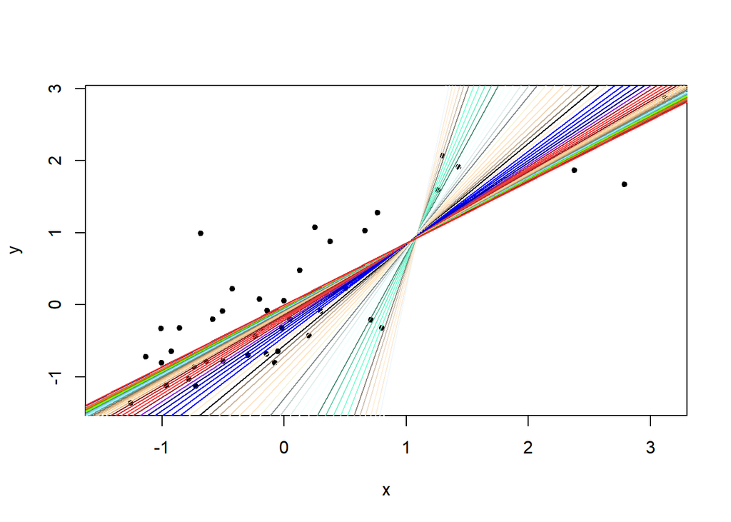

```r
plot(x, y, pch = 20)
rbPal <- colorRampPalette(c('red','blue'))
corrector <- 60
step <- round(resumen_gradDesc$iter/corrector, 0)
color = grDevices::colors()[grep('gr(a|e)y', grDevices::colors(), invert = T)]
for (i in 1:(step-1)) {
  abline(a = resumen_gradDesc$betas[[i*corrector - 1]][1],
         b = resumen_gradDesc$betas[[i*corrector - 1]][2], col = color[i])
}
```

El algoritmo avanza desde la línea más clara a la línea más oscura, la cual es la solución encontrada con el gradiente descendente.

**Ejercicio 1:** Realizar la estimación para los mismos datos (ejemplo de gradiente descendente) mediante la regresión mediana, la función objetivo es el promeio de las distancias de cada dato observado a la línea recta.

## Gradiente descendente en funciones no lineales

El stock de automóviles (expresado en miles) en Holanda en el período 1965 - 1989 es mostrada en la siguiente tabla:

```r
df_stocks <- data.frame(tiempo = 1965:1989, stock = c(1273, 1502, 1696,
              1952, 2212, 2465, 2702, 2903, 3080, 3214, 3399,
              3629, 3851, 4056, 4312, 4515, 4594, 4630, 4728,
              4818, 4901, 4950, 5118, 5251, 5371))
```

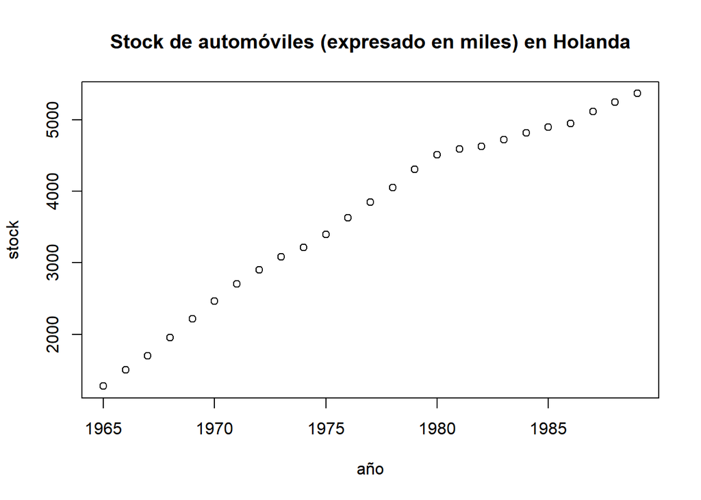

```r
plot(df_stocks$tiempo, df_stocks$stock, xlab = 'año', ylab = 'stock', main = 'Stock de automóviles (expresado en miles) en Holanda')
```

El modelo Gumpertz establece relaciones no lineales:

$$y=e^{a-be^{-cx}}$$
Con $b, c > 0$, $a \in \mathbb{R}$

La función de costo es:

$$\frac{1}{n}\sum_{i=1}^{n}\left( y_i-e^{a-be^{-cx}}\right)^2$$
Modelos no lineales[^1]:

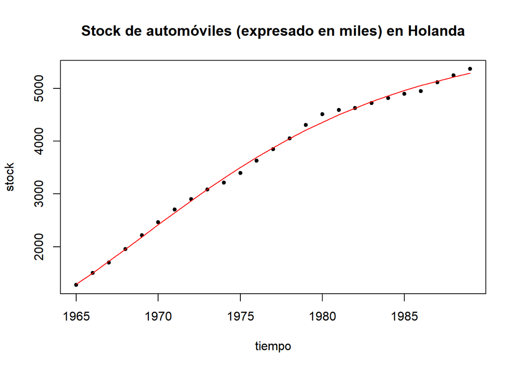

```r
x <- df_stocks$tiempo - 1965
y <- df_stocks$stock
y <- y / 1000
mse_gumpertz <- function(theta) {
   mean((y - exp(theta[1] - theta[2]*exp(-theta[3]*x)))^2)
}
# Restricciones
library(nloptr)
opts = list("algorithm" = "NLOPT_LN_BOBYQA", "xtol_rel" = 1.0e-16, "maxeval" = 10000)
optimizacion <- nloptr(x0 = c(8, 1, 1), eval_f = mse_gumpertz, lb = c(-Inf, 0, 0),
        ub = c(Inf, Inf, Inf), eval_grad_f = NULL, opts = opts)
plot(x + 1965, y*1000, pch = 20, main = 'Stock de automóviles (expresado en miles) en Holanda', xlab = 'tiempo', ylab = 'stock')
lines(x + 1965, exp(optimizacion$solution[1] - optimizacion$solution[2]*exp(-optimizacion$solution[3]*x))*1000, col = "red")
```

En rojo el ajuste al **modelo de Gumpertz**.

[^1]: https://www.statforbiology.com/nonlinearregression/usefulequations#gompertz_curve